[figure not shown]

# Pinguins de Palmer

Uma análise estatística ecológica

Autores

Afiliação

Fernando Andrade

IBB/UNESP

Elias Oliveira Vieira dos Santos

IBB/UNESP

Gabriel Marques Gonzalez

IBB/UNESP

# 1 Introdução

## 1.1 O cenário climático

Notícias recentes como [Planeta atinge 1º ponto crítico climático catastrófico e irreversível](https://www.cnnbrasil.com.br/tecnologia/planeta-atinge-1o-ponto-critico-climatico-catastrofico-e-irreversivel/) (CNN BRASIL, 2025) são impactantes e evidenciam a necessidade de estudos sobre mudanças climáticas.

- Embora seja um alerta global, os efeitos mais críticos são frequentemente observados nos polos;
- A Península Antártica é uma das regiões de aquecimento mais rápido do planeta;
- O Arquipélago de Palmer atua como um “laboratório natural” para estudar as consequências ecológicas.

Arquipélago de Palmer abriga três espécies de Pinguins do gênero *Pygoscelis*: Gentoo (*Pygoscelis papua*), Adelie (*Pygoscelis adeliae*) e Chinstrap (*Pygoscelis antarcticus*).

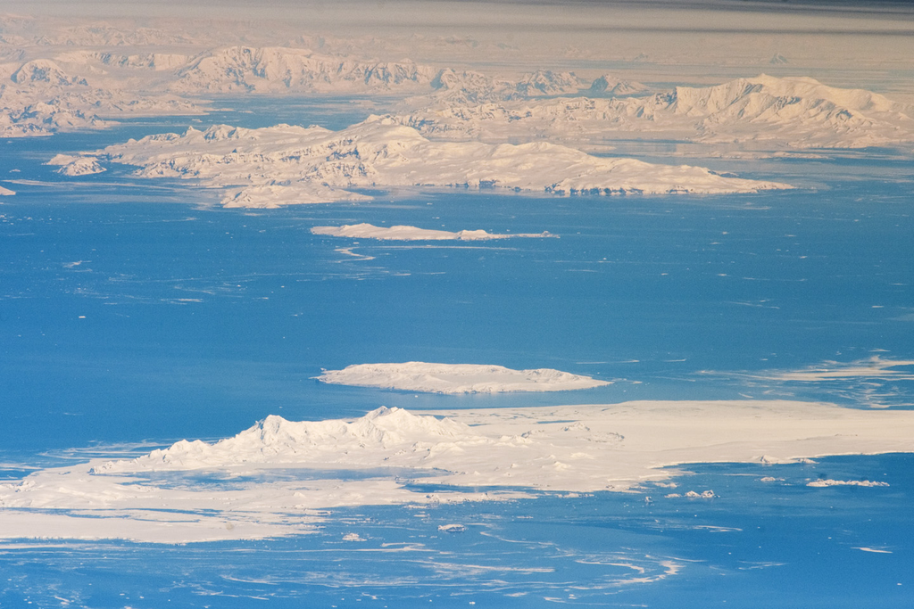

## 1.2 Objetivo de estudo

O impacto das mudanças climáticas sobre as populações de pinguins não são iguais para cada espécie, devido, principalmente, às distintas afinidades ecológicas.

Neste sentido, o objetivo do trabalho é investigar a relação entre as variáveis climáticas – temperaturas e precipitação – e a dinâmica populacional de pinguins do gênero *Pygoscelis*. Em particular:

- Contabilizar a porcentagem entre sexo por espécies, avaliando as relações entre sexo, tamanho do bico e comprimento do bico;
- Contabilizar a frequência das espécies por ilha;
- Avaliar tendências de temperatura do ar, da superfície do mar e precipitação.

# 2 Conhecendo os pinguins

A Tabela 1 resume as principais características de cada espécie, com foco em sua ecologia e vulnerabilidade às mudanças climáticas.

Tabela 1: Resumo comparativo das três espécies de pinguins (Pygoscelis) do Arquipélago de Palmer. Fonte: Penguins International (2025); Secret Atlas (2025); National Geographic Kids (2025); MarineBio (2025).

| Característica | Gentoo | Adelie | Chinstrap |
| --- | --- | --- | --- |
| Porte Físico | Grande (5-8 kg) | Médio (3-6 kg) | Médio (3-6 kg) |
| Marcas Distintivas | Faixa branca no topo da cabeça e bico vermelho-alaranjado vibrante | Anel branco distintivo ao redor dos olhos | Fina faixa preta sob o queixo, "barbicha" |
| Distribuição | A mais ampla e adaptável das três, habitando desde costas rochosas a ilhas com gelo | Estritamente Antártico, nidificando no continente e ilhas adjacentes | Habita ilhas e costas no Pacífico Sul e no setor Antártico |
| Ecologia | Prefere águas abertas para forrageamento. Sua adaptabilidade e menor dependência do gelo o tornam um potencial "vencedor", expandindo seu território para o sul à medida que o gelo recua. | Fortemente dependente do gelo marinho para descanso e acesso a áreas de alimentação (krill). Sua população é altamente vulnerável ao recuo do gelo. | Fortemente dependente do gelo marinho para descanso e acesso a áreas de alimentação (krill). Sua população é altamente vulnerável ao recuo do gelo. |

Horst et al. (2020).

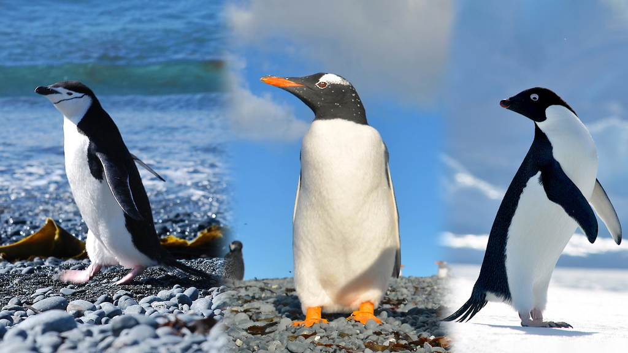

Os pínguins: Chinstrap, Gentoo e Adélie.

# 3 Conjunto de dados

Para explorar a relação entre o clima e a ecologia dos pinguins, dois conjuntos de dados principais serão utilizados.

## 3.1 Dados Meteorológicos

O contexto ambiental é fornecido pelos dados diários da estação meteorológica de Palmer (LTER, 2024). Entre as variáveis disponíveis (ver Tabela 3), as variáveis de temperatura serão o foco principal do estudo.

## 3.2 Dados Biológicos

O conjunto de dados sobre os pinguins do arquipélago de Palmer está livremente disponíveis e pode ser acessado facilmente através do pacote `palmerpenguins` no R (R CORE TEAM, 2025). que disponibiliza os dados originalmente publicados por Gorman et al. (2014). Há dois datasets contidos nessa biblioteca: `penguins` (versão limpa) e `penguins_raw` (dados bruta).

A descrição completa dos dados brutos está presente na Tabela 2. Entre as variáveis disponíveis, serão utilizadas `Species`, `Island`, `Culmen Length`, `Culmen Depth`, `Body Mass`, `Sex`. Também espera-se utilizar as variáveis `Delta 15 N` e `Delta 13 C`, pois os isótopos estáveis são indicadores da dieta a nível trófico dos pinguins.

Tabela 2: Descrição das variáveis do conjunto de dados `penguins_raw`.

| Variável | Tipo | Descrição |
| --- | --- | --- |
| studyName | Texto | Identificação do estudo/expedição |
| Sample Number | Numérica | Número da amostra |
| Species | Fator | Espécie do pinguim |
| Region | Fator | Região da coleta |
| Island | Factor | Ilha onde o pinguim foi registrado |
| Stage | Fator | Estágio do ciclo reprodutivo |
| Individual ID | Texto | Identificador individual do pinguim |
| Clutch Completion | Fator | Se os ovos completaram o ciclo (Yes/No) |
| Date Egg | Data | Data da postura do ovo |
| Culmen Length (mm) | Numérica | Comprimento do bico (mm) |
| Culmen Depth (mm) | Numérica | Profundidade do bico (mm) |
| Flipper Length (mm) | Numérica | Comprimento da nadadeira (mm) |
| Body Mass (g) | Numérica | Massa corporal (g) |
| Sex | Fator | Sexo do pinguim (Male/Female) |
| Delta 15 N (o/oo) | Numérica | Isótopo $\delta {}^{15}$N (‰) |
| Delta 13 C (o/oo) | Numérica | Isótopo $\delta {}^{13}$C (‰) |
| Comments | Texto | Comentários adicionais do pesquisador |

Tabela 3: Descrição das variáveis do conjunto de dados meteorológico na estação de Palmer.

| Variável | Tipo | Descrição |
| --- | --- | --- |
| Date | Data | Dia da medição meteorológica |
| Temperature.High..C. | Numérica | Temperatura máxima diária (°C) |
| Temperature.Low..C. | Numérica | Temperatura mínima diária (°C) |
| Temperature.Average..C. | Numérica | Temperatura média diária (°C) |
| Sea.Surface.Temperature..C. | Numérica | Temperatura da superfície do mar (°C) |
| Sea.Ice..WMO.Code. | Fator | Código WMO de condição de gelo no mar |
| Pressure.High..mbar. | Numérica | Pressão atmosférica máxima (mbar) |
| Pressure.Low..mbar. | Numérica | Pressão atmosférica mínima (mbar) |
| Pressure.Average..mbar. | Numérica | Pressão atmosférica média (mbar) |
| Wind.Peak..knots. | Numérica | Velocidade máxima do vento (nós) |
| Wind.5.Sec.Peak..knots. | Numérica | Pico do vento em intervalo de 5s (nós) |
| Wind.2.Min.Peak..knots. | Numérica | Pico do vento em intervalo de 2min (nós) |
| Wind.Average..knots. | Numérica | Velocidade média do vento (nós) |
| Wind.Peak.Direction | Numérica | Direção (graus) do pico de vento |
| Wind.5.Sec.Peak.Direction | Numérica | Direção do vento em pico de 5s |
| Wind.2.Min.Peak.Direction | Numérica | Direção do vento em pico de 2min |
| Wind.Prevailing.Direction | Fator | Direção predominante do vento |
| Precipitation.Melted..mm. | Numérica | Precipitação derretida (mm) |
| Precipitation.Snow..cm. | Numérica | Precipitação de neve (cm) |
| Depth.at.Snowstake..cm. | Numérica | Profundidade da neve medida (cm) |
| Sky.Coverage..tenths. | Numérica | Cobertura do céu ($10^{-1}$) |

# 4 Análise Exploratória dos Dados

1. Validação da Amostra: Equilíbrio Sexual
2. Contexto Amostral: Distribuição Geográfica
3. Biometria: Massa Corporal e Dimorfismo
4. Evidência de Nicho Ecológico: Morfologia do Bico
5. Síntese: Evidência de Nicho Trófico

## 4.1 Validação da Amostra: Equilíbrio Sexual

Tabela 4: Contagem e Percentual de Sexo por Espécie.

| Espécie | Sexo | Contagem | Percentual_Especie |
| --- | --- | --- | --- |
| Adelie | Fêmea | 73 | 50.00 |
| Adelie | Macho | 73 | 50.00 |
| Chinstrap | Fêmea | 34 | 50.00 |
| Chinstrap | Macho | 34 | 50.00 |
| Gentoo | Fêmea | 58 | 48.74 |
| Gentoo | Macho | 61 | 51.26 |

## 4.2 Contexto Amostral: Distribuição Geográfica

Tabela 5: Distribuição de Frequência das Espécies de Pinguins por Ilha.

| Espécie | Ilha | Contagem | Percentual |
| --- | --- | --- | --- |
| Adelie | Biscoe | 44 | 12.79 |
| Adelie | Dream | 56 | 16.28 |
| Adelie | Torgersen | 52 | 15.12 |
| Chinstrap | Dream | 68 | 19.77 |
| Gentoo | Biscoe | 124 | 36.05 |

- **Gentoo** domina a amostra (36%), concentrado em Biscoe;
- **Adelie** é a espécie mais dispersa.

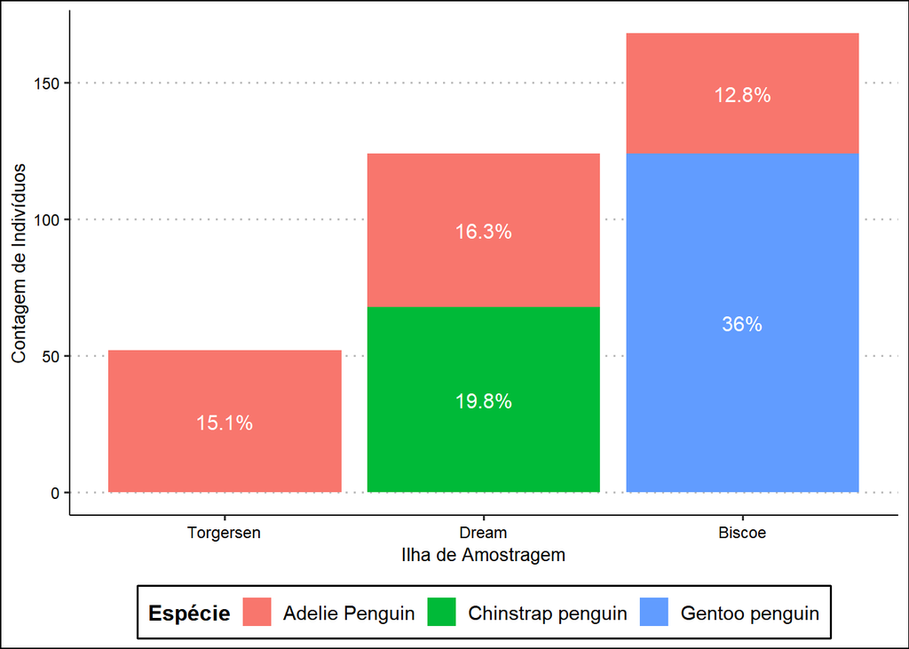

Figura 1: Distribuição da Amostra de Pinguins por Ilha e Espécie: Contexto Espacial e Amostral no Arquipélago de Palmer.

## 4.3 Biometria: Massa Corporal e Dimorfismo

Tabela 6: Estatísticas Descritivas Completas da Massa Corporal por Espécie e Sexo.

| Espécie | Sexo | N | Média (g) | Desvio (g) | Mínimo (g) | Mediana (g) | Máximo (g) |
| --- | --- | --- | --- | --- | --- | --- | --- |
| Adelie | Fêmea | 73 | 3368.84 | 269.38 | 2850 | 3400 | 3900 |
| Adelie | Macho | 73 | 4043.49 | 346.81 | 3325 | 4000 | 4775 |
| Chinstrap | Fêmea | 34 | 3527.21 | 285.33 | 2700 | 3550 | 4150 |
| Chinstrap | Macho | 34 | 3938.97 | 362.14 | 3250 | 3950 | 4800 |
| Gentoo | Fêmea | 58 | 4679.74 | 281.58 | 3950 | 4700 | 5200 |
| Gentoo | Macho | 61 | 5484.84 | 313.16 | 4750 | 5500 | 6300 |

- Em todas as espécies, os machos são mais pesados que as fêmeas;
- O **Gentoo Macho** é notavelmente maior ($\approx 5.5$kg) que qualquer outro grupo, reforçando sua posição de “vencedor” em porte físico;
- O **mínimo** do Gentoo Macho (4750g) tem um valor próximo **máximo** do Adelie Macho (4775g), indicando que quase nenhuma sobreposição de tamanho.

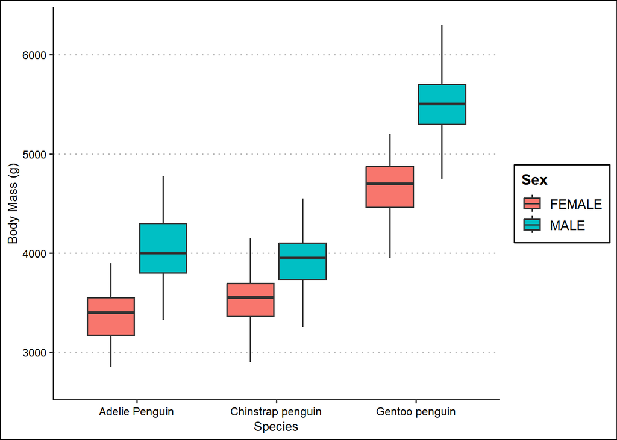

Figura 2: Massa Corporal por Espécie e Dimorfismo Sexual.

## 4.4 Evidência de Nicho Ecológico: Morfologia do Bico

Tabela 7: Médias de Massa e Morfológicas por Espécie e Sexo.

| Espécie | Sexo | N | Massa Média (g) | Comp. Bico Médio (mm) | Prof. Bico Média (mm) |
| --- | --- | --- | --- | --- | --- |
| Adelie | Fêmea | 73 | 3368.84 | 37.26 | 17.62 |
| Adelie | Macho | 73 | 4043.49 | 40.39 | 19.07 |
| Chinstrap | Fêmea | 34 | 3527.21 | 46.57 | 17.59 |
| Chinstrap | Macho | 34 | 3938.97 | 51.09 | 19.25 |
| Gentoo | Fêmea | 58 | 4679.74 | 45.56 | 14.24 |
| Gentoo | Macho | 61 | 5484.84 | 49.47 | 15.72 |

Os dados confirmam que as diferenças não apenas em relação ao peso, mas estruturais (tamanho e forma do bico), sugerindo adaptações diferentes para forrageamento.

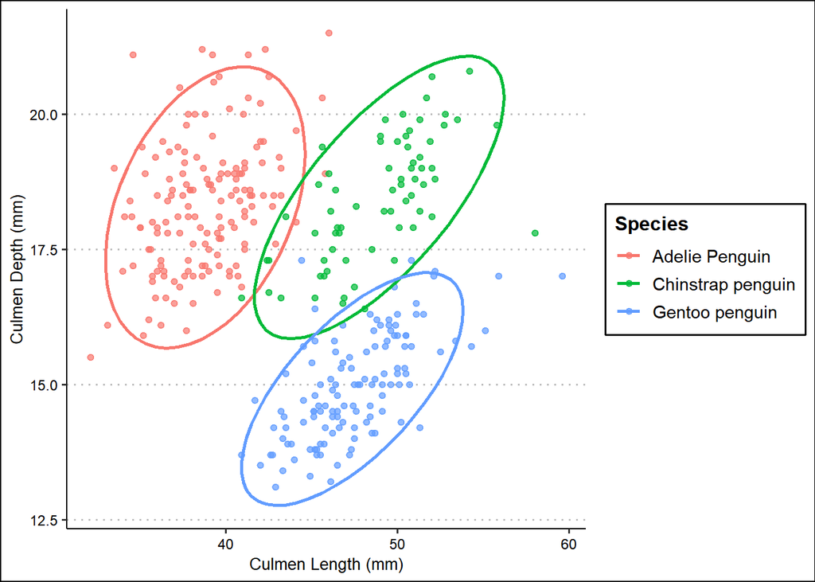

Figura 3: Relação Comprimento vs. Profundidade do Bico.

## 4.5 Síntese: Evidência de Nicho Trófico

Tabela 8: Comparação de Médias Biométricas e Tróficas por Espécie e Sexo

| Espécie | Sexo | N | Massa Média (g) | Comp. Bico Médio (mm) | Prof. Bico Média (mm) | Delta 15N Médio (o/oo) | Delta 13C Médio (o/oo) |
| --- | --- | --- | --- | --- | --- | --- | --- |
| Adelie | Fêmea | 71 | 3366.55 | 37.21 | 17.62 | 8.79 | -25.79 |
| Adelie | Macho | 68 | 4053.68 | 40.43 | 19.06 | 8.93 | -25.83 |
| Chinstrap | Fêmea | 34 | 3527.21 | 46.57 | 17.59 | 9.25 | -24.57 |
| Chinstrap | Macho | 33 | 3938.64 | 51.07 | 19.25 | 9.46 | -24.55 |
| Gentoo | Fêmea | 58 | 4679.74 | 45.56 | 14.24 | 8.19 | -26.20 |
| Gentoo | Macho | 60 | 5488.75 | 49.51 | 15.72 | 8.30 | -26.17 |

As diferenças em isótopos ($\delta{}^{15}$N e $\delta{}^{13}$C) confirmam que as espécies ocupam níveis tróficos e fontes de carbono distintas, validando a hipótese de que a resposta ao clima será diferenciada.

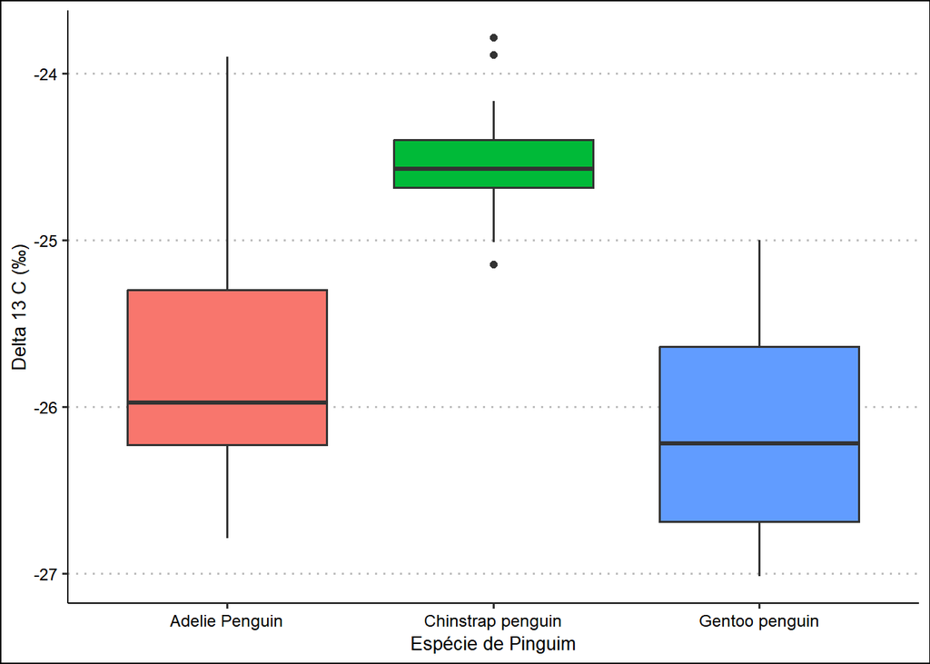

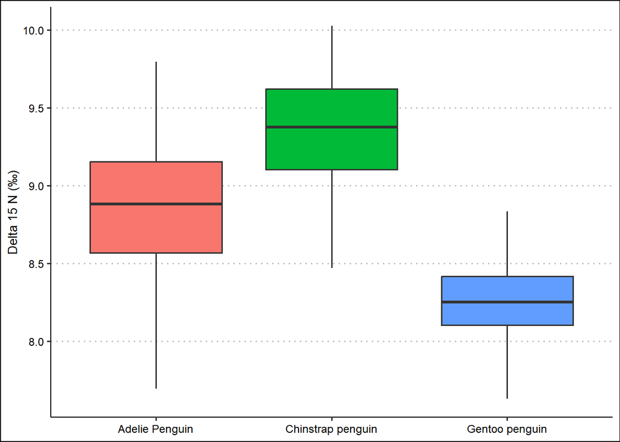

Figura 4: Boxplot da Segregação Espacial e Estratificação alimentar

## 4.6 Temperatura Média do Ar

Através da Tabela 9 verifica-se que há anos com datas incompletas e, também, com valores ausentes.

Tabela 9: Anos completos ou com NAs.

| Ano | Total Dias | Dias com NA |
| --- | --- | --- |
| 1997 | 365 | 0 |
| 1998 | 365 | 0 |
| 1999 | 365 | 0 |
| 2000 | 366 | 0 |
| 2001 | 365 | 0 |
| 2002 | 365 | 0 |
| 2003 | 365 | 0 |
| 2004 | 366 | 0 |
| 2005 | 365 | 0 |
| 2006 | 365 | 8 |
| 2007 | 365 | 0 |
| 2008 | 366 | 0 |
| 2009 | 334 | 0 |
| 2010 | 365 | 0 |
| 2011 | 365 | 0 |
| 2012 | 366 | 0 |
| 2013 | 365 | 0 |
| 2014 | 365 | 0 |
| 2015 | 365 | 0 |
| 2016 | 366 | 0 |
| 2017 | 364 | 0 |
| 2018 | 365 | 0 |
| 2019 | 365 | 0 |
| 2020 | 366 | 2 |
| 2021 | 365 | 0 |
| 2022 | 365 | 0 |
| 2023 | 363 | 0 |

- Em 2009, dos 365 dias, há apenas 334 no conjunto de dados, mas todos com observações. Portanto, há valores ausentes no quesito de dias.
- Em 2006, há 365 dias no conjunto de dados, no entanto, há 8 dias com ausência de informação sobre a Temperatura média.

### 4.6.1 Imputando os dados ausentes

A imputação dos NAs será realizada através do pacote `mice` (VAN BUUREN; GROOTHUIS-OUDSHOORN, 2011) com a opção `pmm`. Em termos didáticos, o processo funciona em três etapas:

1. O algoritmo estima um valor provável para o dado faltante (ex: 3ºC) baseando-se nas correlações com as outras variáveis presentes (como dia do ano e temperatura do ar)
2. Ele busca no banco de dados observações reais (doadores) que tenham características estatísticas muito próximas a essa estimativa;
3. Ele seleciona aleatoriamente um desses doadores e copia o valor real observado para preencher a lacuna.

```r
dados_imputar <- palmerweather %>%
  tsibble::fill_gaps() %>%
  ungroup() %>%
  as.data.frame() %>%
  select(-Date)

imp <- dados_imputar %>%
  mice(method = "pmm", seed = 123)

dados_imputar <- complete(imp)
```

É possível verificar se a imputação foi bem sucedida por meio da função `md.pattern()`. A Figura 5 exibe os padrões dos valores ausente, se existir.

```
 /\     /\
{  `---'  }
{  O   O  }
==>  V <==  No need for mice. This data set is completely observed.
 \  \|/  /
  `-----'
```

```
     Temp_avg Temp_max Temp_min day
9861        1        1        1   1 0
            0        0        0   0 0
```

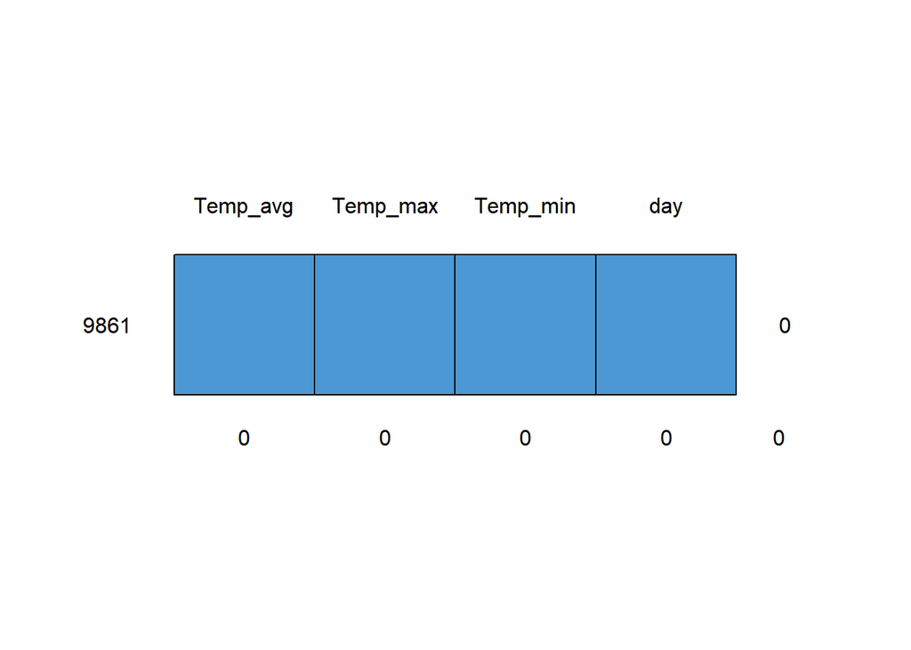

Figura 5: Gráfico de padrões dos valores ausentes.

```r
md.pattern(dados_imputar)
```

### 4.6.2 Medidas resumo

A Tabela 10 exibe as medidas descritivas para a Temperatura Média do Ar após a imputação dos dados ausentes.

Tabela 10: Medidas descritivas para a Temperatura Média do Ar.

| Variável | Min. | 1st Qu. | Median | Mean | 3rd Qu. | Max. |
| --- | --- | --- | --- | --- | --- | --- |
| Temperatura Média do Ar | -23.6 | -3.5 | -0.6 | -1.54 | 1.3 | 7.4 |

## 4.7 Dados de Temperatura da Superfície do Mar e Precipitação

Um outro método para avaliarmos as variáveis com NA é através de gráficos e a função `gg_miss_var()` permite realizar essa inspeção.

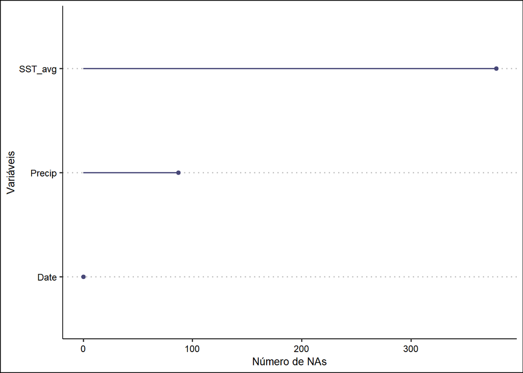

Figura 6: Gráfico de barras com número de NAs por variável. `SST_avg` representa a Temperatura Média da Superfície do Mar; `Precip`, a Preciptação e `Date` as datas diárias.

```r
palmerweather2 %>%
  select(SST_avg, Precip) %>%
  gg_miss_var()+
  labs(x = "Variáveis", y="Número de NAs")+
  theme_clean()
```

Por meio da Figura 6, nota-se que em ambas variáveis contém valores ausentes, com destaque para a `SST_avg` com mais de 300 NAs.

### 4.7.1 Imputando os dados ausentes

A abordagem de imputação foi novamente por meio do `mice`, também com a opção `pmm` para ambas variáveis em abordagem, envolvendo um processo análogo que será ofuscado.

### 4.7.2 Medidas resumo

A Tabela 11 exibe as medidas descritivas para as variáveis apresentadas nesta seção.

Tabela 11: Medidas descritivas para Temperatura Média da Superfície do Mar e Precipitação Média.

| Variável | Min. | 1st Qu. | Median | Mean | 3rd Qu. | Max. |
| --- | --- | --- | --- | --- | --- | --- |
| Temperatura Média da Superfície do Mar | -9.9 | -1.6 | -0.9 | -0.54 | 0.4 | 3.5 |
| Precipitação | 0.0 | 0.0 | 0.3 | 1.82 | 1.8 | 72.9 |

# 5 Análise de Série Temporal

Segundo Morettin; Toloi (2018), uma série temporal é qualquer conjunto de observações ordenadas no tempo, podendo ser discretos ou contínuos. Exemplos práticos incluem dados meteorológicos, tais como `Temperatura` e `Precipitação`, que são coletados em intervalos regulares (diários, mensais, anuais).

Para compreender a estrutura desses dados, utiliza-se a decomposição, um procedimento estatístico que desagrega a série em três componentes fundamentais:

- **Tendência**: representa a direção de longo prazo;
- **Sazonalidade**: corresponde às flutuações periódicas;
- **Resíduos**: abrange as irregularidades aleatórias, isto é, o que não foi capturado pelas outras componentes.

Dentre as técnicas disponíveis, destaca-se a decomposição STL (*Seasonal and Trend decomposition using Loess*) pela sua robustez e flexibilidade.

## 5.1 Decomposição STL das séries temporais

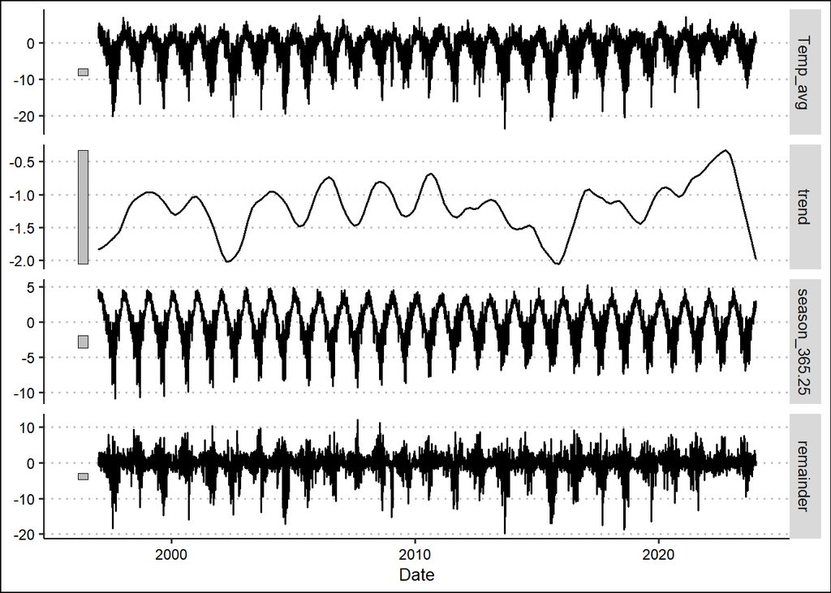

Figura 7: Decomposição STL da Temperatura Média do Ar.

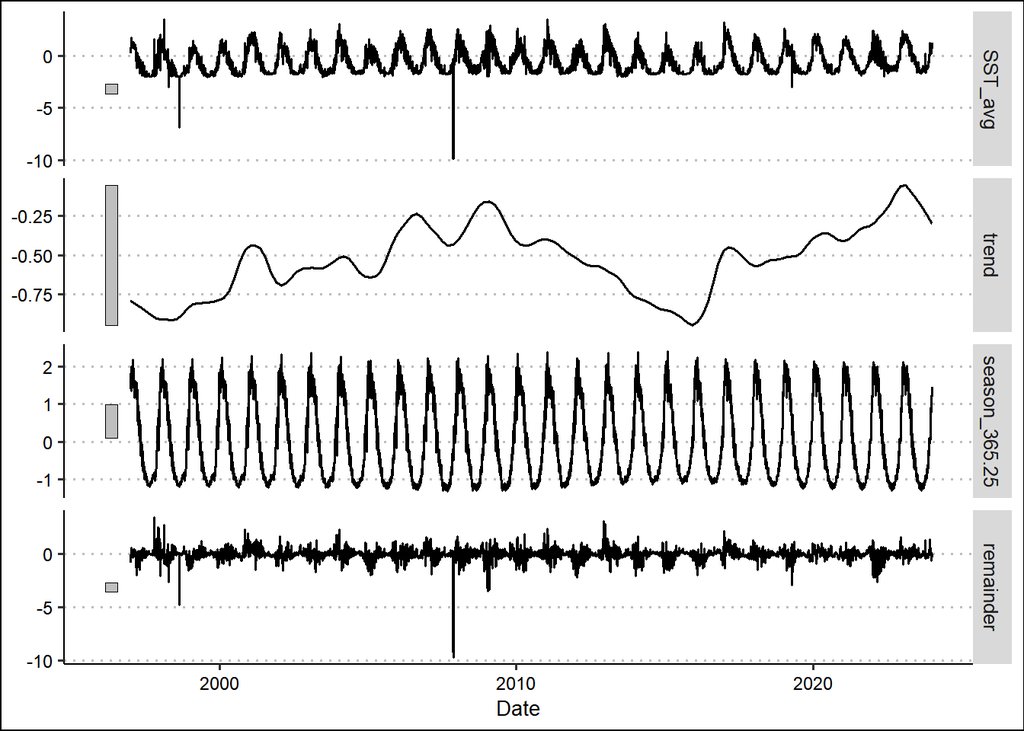

Figura 8: Decomposição STL da Temperatura Média do da Superfície do Mar.

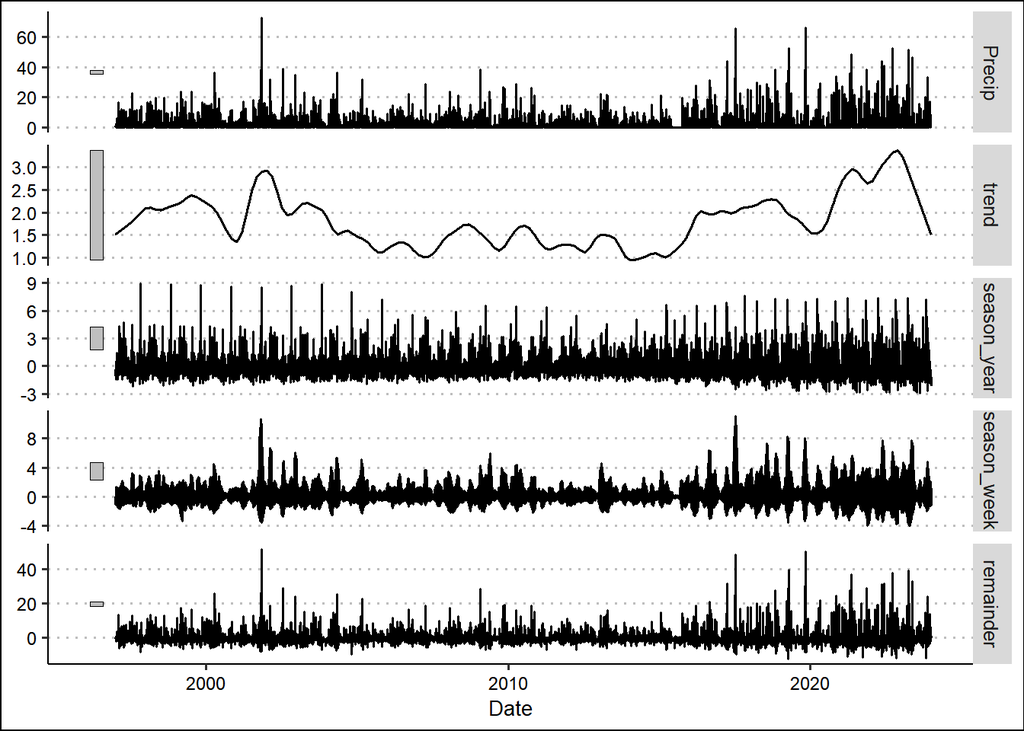

Figura 9: Decomposição STL da Preciptação.

## 5.2 Analisando tendências

Uma metodologia clássica na literatura para analisar tendências em séries temporais de forma robusta é o estimador de inclinação de Sen (SEN, 1968).

A grande vantagem neste método é a sua capacidade de lidar lidar com valores discrepantes, que distorcem uma análise de tendência comum. O teste de hipóteses realizado consiste em testar:

$$\begin{cases}
H_0\colon \text{A tendência é nula} \\
H_1\colon \text{A tendência é não nula}
\end{cases}$$

Os resultados acerca desse teste estão exibidos na Tabela 12.

Tabela 12: Teste de Sen e suas estimativas pontuais e intervalares 95% para tendência.

| Variável | Estimativa | Valor-p | IC Lower | IC Upper |
| --- | --- | --- | --- | --- |
| Temperatura Média do Ar | 3.15e-05 | 0 | 2.88e-05 | 3.42e-05 |
| Temperatura do Mar | 3.96e-05 | 0 | 3.83e-05 | 4.09e-05 |
| Precipitação | 2.05e-05 | 0 | 1.56e-05 | 2.54e-05 |

Uma vez que todos os valores-$p$ foram iguais a zero e, portanto, menor que $\alpha = 0.05$ de significância, rejeita-se $H_0$. Portanto, a tendência em todas as séries temporais são estatisticamente significantes.

## 5.3 Visualizando a tendência

A Figura 10 permite visualizarmos com clareza a tendência a cerca das séries temporais sobre as variáveis em estudo.

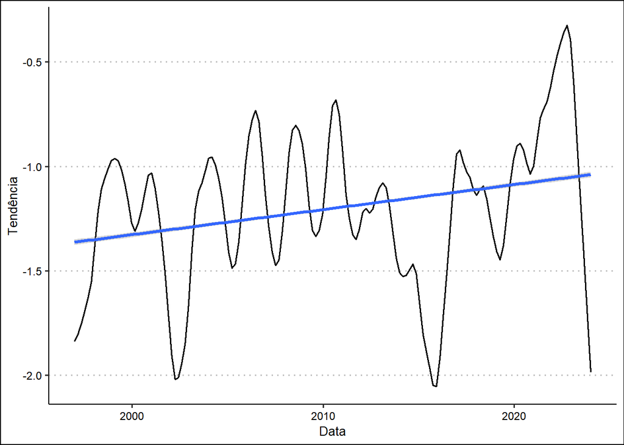

(a) Temperatura Média do Ar

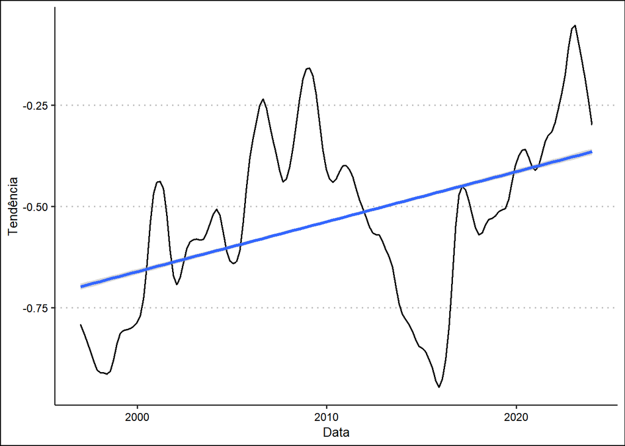

(b) Temperatura do Mar

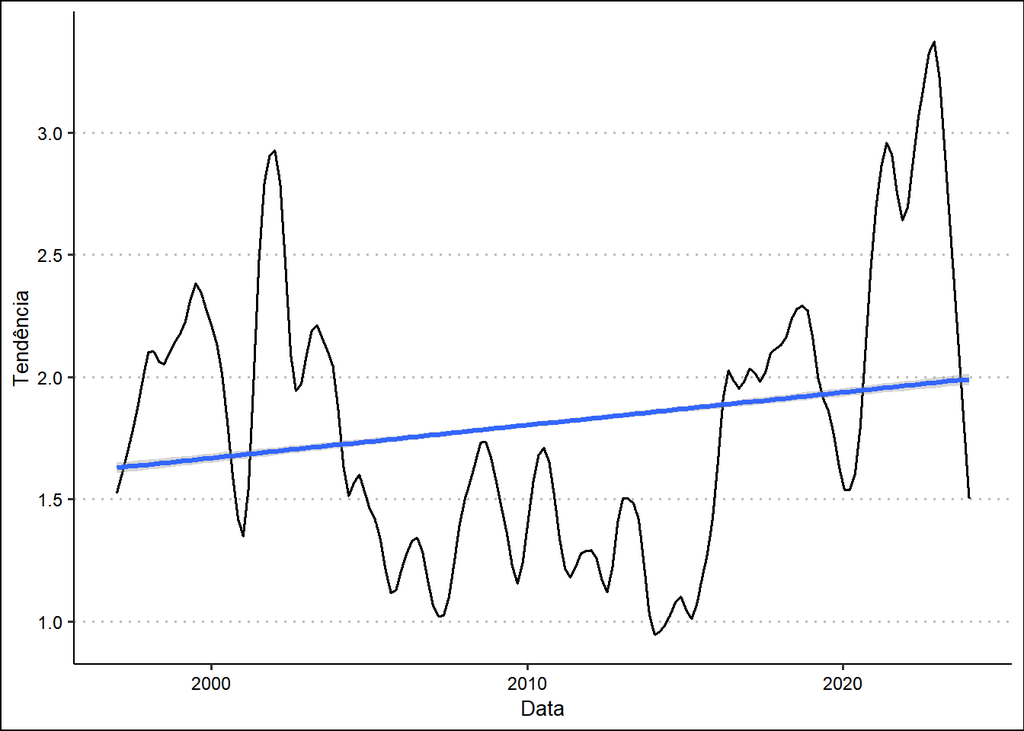

(c) Precipitação

Figura 10: A reta ajustada para exibir a tendência nas séries temporais.

## 5.4 Conclusões

Como evidenciado, há uma tendência significativa de aumento para a Temperatura Média do Ar, Temperatura da Superfície do Mar e Precipitação. Com isso:

- O aquecimento do ar e do mar induz a retração das plataformas de gelo. Isso reduz o habitat das espécies dependentes de gelo (Adélie e Chinstrap), enquanto favorece a expansão de espécies generalistas que evitam gelo denso (Gentoo).
- O aumento da precipitação eleva o risco de mortalidade de filhotes por hipotermia, visto que a penugem molhada perde o isolamento térmico e prejudica a nidificação pelo acúmulo de lama.
- Neste cenário, consolida-se a dinâmica de “Vencedores” e “Perdedores”, com o Gentoo tende a prevalecer populacionalmente sobre as espécies especialistas.

# 6 Agradecimentos

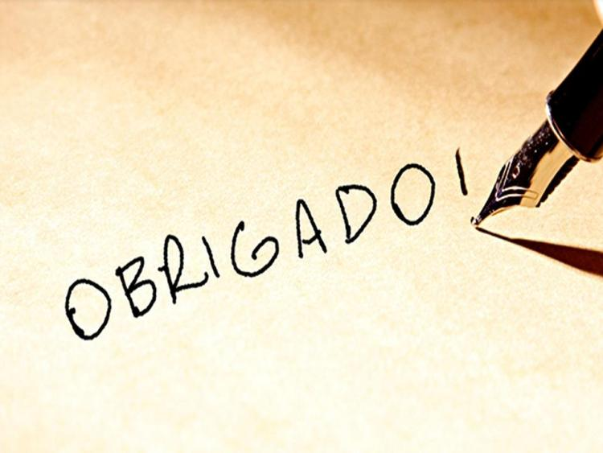

## Referências

CNN BRASIL. **Planeta atinge 1º ponto crítico climático catastrófico e irreversível**. CNN Brasil, 14 out. 2025. Disponível em: <https://www.cnnbrasil.com.br/tecnologia/planeta-atinge-1o-ponto-critico-climatico-catastrofico-e-irreversivel/>

GORMAN, Kristen B. *et al.* [Ecological Sexual Dimorphism and Environmental Variability within a Community of Antarctic Penguins (Genus Pygoscelis)](https://doi.org/10.1371/journal.pone.0090081). **PLOS ONE**, v. 9, n. 3, p. e90081, 2014.

HORST, Allison Marie *et al.* **[palmerpenguins: Palmer Archipelago (Antarctica) penguin data](https://doi.org/10.5281/zenodo.3960218)**. *[S.l.: S.n.]*.

LTER, Palmer Station Antarctica. **Daily weather averages for Palmer Station, Antarctica (1989-2024)**. Environmental Data Initiative, 2024.

MARINEBIO. **Chinstrap Penguins, Pygoscelis antarcticus**. MarineBio, 2025. Disponível em: <https://www.marinebio.org/species/chinstrap-penguins/pygoscelis-antarcticus/>

MORETTIN, Pedro A.; TOLOI, Clélia M. C. **Análise de Séries Temporais: modelos lineares univariados**. 3. ed. São Paulo, SP: Blucher, 2018. v. 1

NATIONAL GEOGRAPHIC KIDS. **Adélie Penguin**. National Geographic Kids, 2025. Disponível em: <https://kids.nationalgeographic.com/animals/birds/facts/adelie-penguin>

PENGUINS INTERNATIONAL. **Penguins Species**. Penguins International, 2025. Disponível em: <https://www.penguinsinternational.org/penguin-species>

R CORE TEAM. **[R: A Language and Environment for Statistical Computing](https://www.R-project.org/)**. Vienna, Austria: R Foundation for Statistical Computing, 2025.

SECRET ATLAS. **Gentoo Penguins in the Wild: Habtitat & Behavior Guide**. Secret Atlas, 2025. Disponível em: <https://www.secretatlas.com/handbook/wildlife-and-nature-guides/antarctic/gentoo-penguins>

SEN, Pranab Kumar. [Estimates of the Regression Coefficient Based on Kendall’s Tau](https://doi.org/10.1080/01621459.1968.10480934). **Journal of the American Statistical Association**, v. 63, n. 324, p. 1379–1389, dez. 1968.

VAN BUUREN, Stef; GROOTHUIS-OUDSHOORN, Karin. [mice: Multivariate Imputation by Chained Equations in R](https://doi.org/10.18637/jss.v045.i03). **Journal of Statistical Software**, v. 45, n. 3, p. 1–67, 2011.